# Data Analysis Protocol DOMn4

## The code

### Install packages

```python
# !pip install pandas
# !pip install numpy
# !pip install matplotlib
# !pip install seaborn
# !pip install scikit-learn
```

### Import packages

```python
import pandas as pd # creating and working with dataframes
import numpy as np # creating and manipulating arrays
import tabulate # creating html tables in notebook (also accepts LaTeX format)
from pandas.plotting import scatter_matrix
from sklearn.preprocessing import StandardScaler
from sklearn.model_selection import train_test_split
import seaborn as sns # making beautiful images
import matplotlib.pyplot as plt # visualizing data
from sklearn.tree import DecisionTreeClassifier
from sklearn.linear_model import LinearRegression
from sklearn.linear_model import LogisticRegression
from sklearn.neighbors import KNeighborsClassifier
from sklearn import tree
```

### Read in table

This step takes the table and converts it to a machine readable format.

```python
df_Text = pd.read_csv('table_Text_actual', delimiter=',')



table = tabulate.tabulate(df_Text, tablefmt='html',headers="keys")
table
```

|  | word | sentence | language | text | sentence_number | word_num | previous_men | distance | theta_role | stem | oblique | number | gender | attribution | semantic_class_animacy | quantification | definiteness_marked | definiteness_type | enumerated | verb_dist |
| --- | --- | --- | --- | --- | --- | --- | --- | --- | --- | --- | --- | --- | --- | --- | --- | --- | --- | --- | --- | --- |
| 0 | heywānekey | e čā xizone eškewtēwe. heywāndāre heywānekeyš bero memliketē čoɫū. | H Text | ZB | 5 | 30 | 0 | 0 | P | prs | 1 | sg | m | na | ? | ? | def | ? | ? | 2 |
| 1 | āsmān | māčo, `be xwā wāro. ānā hewrē sīyāw pise četrē kewt āsmān.’ | H Text | ZB | 17 | 139 | 1 | 0 | P | pst | 0 | sg | m | na | ? | ? | abs | ? | ? | 1 |
| 2 | heywāne | heywāne āwē berde. | H Text | ZB | 21 | 165 | 0 | 0 | P | pst | 0 | sg | f | na | ? | ? | abs | ? | ? | 2 |
| 3 | ħeywānē | ħeywānē miđā wer. girđ wizāš weɫē. | H Text | ZB | 31 | 260 | 0 | 0 | P | prs | 0 | pl | m | na | ? | ? | abs | ? | ? | 4 |
| 4 | kuřekey | milā ew kuřekey yoyšā berā. ānešā zilterū ʕālter bo āđī berā. | H Text | ZB | 40 | 328 | 3 | 0 | P | prs | 1 | sg | m | na | ? | ? | def | deict | ? | 11 |
| 5 | pey | pey minyo serū nerekeyū čērhur zāroɫeke šot wero. | H Text | ZB | 45 | 374 | 2 | 0 | P | prs | 0 | sg | m | na | ? | ? | abs | ? | ? | 9 |
| 6 | šot | pey minyo serū nerekeyū čērhur zāroɫeke šot wero. | H Text | ZB | 45 | 382 | 0 | 0 | P | prs | 0 | sg | m | na | ? | ? | abs | ? | ? | 1 |
| 7 | sere | wextē miđyo kābrā qiřoɫū nerekeyne sere ber mēw milo řū zemīnīre. | H Text | ZB | 48 | 408 | 0 | 0 | P | prs | 0 | sg | m | na | ? | ? | abs | ? | ? | 4 |
| 8 | kīloē | mārowe kēšoš šiš kīloē. | H Text | ZB | 51 | 437 | 0 | 0 | P | prs | 0 | pl | m | na | ? | ? | abs | ? | ? | 3 |
| 9 | kīloē | hinū dilū qiřoɫū nerekey šiš kīloē čīđī zīyā bo. | H Text | ZB | 52 | 443 | 1 | 0 | P | prs | 0 | pl | m | na | ? | ? | abs | ? | ? | 4 |
| 10 | kuřekey | wextē kuřekey māro milo řūešo wāčē pēse nečīrī piřā, piřā. | H Text | ZB | 56 | 477 | 4 | 0 | P | pst | 1 | sg | m | na | ? | ? | def | ? | ? | 10 |
| 11 | kīloē | hāɫbete bero gēroš. kēštebēš šiš kīloē āđ čewī zīyāter bīyebē. | H Text | ZB | 57 | 496 | 2 | 0 | P | prs | 0 | pl | m | na | ? | ? | abs | ? | ? | 6 |
| 12 | herčē | herčēšā kerdebo herčēšā wātebo lā xwāywe qisēšā meqboɫe bīyēne. | H Text | ZB | 59 | 509 | 0 | 0 | P | pst | 0 | sg | m | na | ? | ? | abs | ? | ? | 14 |
| 13 | herčē | herčēšā kerdebo herčēšā wātebo lā xwāywe qisēšā meqboɫe bīyēne. | H Text | ZB | 59 | 513 | 1 | 0 | P | pst | 0 | sg | m | na | ? | ? | abs | ? | ? | 10 |
| 14 | nāmē | vātiš, qurbān xuɫkū fiɫāne yāgēnmē deg{\textepsilon | H Text | ZQ | 5 | 586 | 0 | 0 | P | pst | 0 | sg | f | na | ? | ? | abs | ? | ? | 1 |
| 15 | čēš | fermāwāš, dā dey řoɫe čēš māčī?’ | H Text | ZQ | 8 | 613 | 2 | 0 | P | prs | 0 | sg | m | na | ? | ? | abs | ? | ? | 1 |
| 16 | gīyāne | yoyčšā her gīyāne gūwīnēš čenī bē melāqāt. | H Text | ZQ | 19 | 717 | 0 | 0 | P | prs | 0 | sg | m | att | ? | ? | abs | ? | ? | 4 |
| 17 | yo | yošā kerdmā bāboɫē ārdmā. | H Text | ZQ | 22 | 741 | 5 | 0 | P | pst | 0 | sg | m | na | ? | ? | abs | ? | ? | 5 |
| 18 | yo | yošā berd nīyāmne qiřoɫe dāreke qurbān. | H Text | ZQ | 26 | 791 | 7 | 0 | P | pst | 0 | sg | m | na | ? | ? | abs | ? | ? | 3 |
| 19 | deseɫātē | xwāy deseɫātē čāneš bīyen ī pīfēše weše kerdēne. | H Text | ZQ | 42 | 933 | 0 | 0 | P | pst | 0 | sg | m | na | ? | ? | indf | na | ? | 10 |
| 20 | pīfē | xwāy deseɫātē čāneš bīyen ī pīfēše weše kerdēne. | H Text | ZQ | 42 | 939 | 1 | 0 | P | pst | 0 | sg | f | na | ? | ? | abs | deict | ? | 4 |
| 21 | čēš | vātšā, `čēš māčī?’ | H Text | ZQ | 51 | 1007 | 4 | 0 | P | prs | 0 | sg | m | na | ? | ? | abs | ? | ? | 1 |
| 22 | deseɫāt | fermāwo, dey āne ētir deseɫāt xwāy, pey her čē meyliš bē xwāy deseɫātē čānēš henē | H Text | ZQ | 55 | 1061 | 1 | 0 | P | prs | 0 | sg | m | na | ? | ? | abs | ? | ? | 6 |
| 23 | herčē | fermāwo, dey āne ētir deseɫāt xwāy, pey her čē meyliš bē xwāy deseɫātē čānēš henē | H Text | ZQ | 55 | 1064 | 2 | 0 | P | prs | 0 | sg | m | na | ? | ? | abs | ? | ? | 3 |
| 24 | deseɫātē | fermāwo, dey āne ētir deseɫāt xwāy, pey her čē meyliš bē xwāy deseɫātē čānēš henē | H Text | ZQ | 55 | 1069 | 2 | 0 | P | prs | 0 | pl | m | na | ? | ? | abs | ? | ? | 2 |
| 25 | herē | herēšā bo pey bārīšā bilā bārāw bilā bēnēve. | H Text | HB | 9 | 1155 | 11 | 0 | P | prs | 0 | sg | m | na | ? | ? | indf | na | ? | 10 |
| 26 | bār | min... bilā bēnēve, bilā bāršā pey bāro bāršā pey bero. | H Text | HB | 10 | 1172 | 2 | 0 | P | prs | 0 | sg | m | na | ? | ? | abs | ? | ? | 7 |
| 27 | bār | min... bilā bēnēve, bilā bāršā pey bāro bāršā pey bero. | H Text | HB | 10 | 1176 | 3 | 0 | P | prs | 0 | sg | m | na | ? | ? | abs | ? | ? | 3 |
| 28 | herekey | fermāwo, `dā lodē wāčdē be fiɫāne kesī bilo herekey bero. | H Text | HB | 11 | 1188 | 12 | 0 | P | prs | 1 | sg | m | na | ? | ? | def | ? | ? | 1 |
| 29 | hereī | kābrāyč herbenew hereyn, milo herey gurj kerowew gino řā. | H Text | HB | 15 | 1210 | 13 | 0 | P | prs | 1 | sg | m | na | ? | ? | def | ? | ? | 8 |

[output cut: 312 more lines]

### Hot encode categorical variables

```python
#perform get_dummies on stem
dummy = pd.get_dummies(df_Text.stem, prefix='stem', prefix_sep='_', dtype='int64')
df_Text = df_Text.join(dummy)

#perform get_dummies on number
dummy = pd.get_dummies(df_Text.number, prefix='number', prefix_sep='_', dtype='int64')
df_Text = df_Text.join(dummy)

#perform get_dummies on gender
dummy = pd.get_dummies(df_Text.gender, prefix='gender', prefix_sep='_', dtype='int64')
df_Text = df_Text.join(dummy)

# # stem to binary
# binary_dict = {'pst':1, 'prs':0}
# df_Text['stem'] = df_Text['stem'].map(binary_dict)

# # number to binary
# binary_dict = {'pl':1, 'sg':0}
# df_Text['number'] = df_Text['number'].map(binary_dict)

# # gender to binary
# binary_dict = {'f':1, 'm':0}
# df_Text['gender'] = df_Text['gender'].map(binary_dict)

#perform get_dummies on attribution
dummy = pd.get_dummies(df_Text.attribution, prefix='ez', prefix_sep='_', dtype='int64')
df_Text = df_Text.join(dummy)

#perform get_dummies on definiteness_marked
dummy = pd.get_dummies(df_Text.definiteness_marked,prefix='def_m', prefix_sep='_', dtype='int64')
df_Text = df_Text.join(dummy)
df_Text = df_Text.drop(columns=['gender', 'number', 'stem', 'word', 'attribution', 'semantic_class_animacy', 'quantification', 'definiteness_marked', 'definiteness_type', 'enumerated', 'theta_role', 'sentence', 'language', 'text', 'sentence_number',  'word_num'])

table = tabulate.tabulate(df_Text, tablefmt='html',headers="keys")
table
```

|  | previous_men | distance | oblique | verb_dist | stem_prs | stem_pst | number_pl | number_sg | gender_f | gender_m | ez_att | ez_gen | ez_na | def_m_abs | def_m_def | def_m_indf |
| --- | --- | --- | --- | --- | --- | --- | --- | --- | --- | --- | --- | --- | --- | --- | --- | --- |
| 0 | 0 | 0 | 1 | 2 | 1 | 0 | 0 | 1 | 0 | 1 | 0 | 0 | 1 | 0 | 1 | 0 |
| 1 | 1 | 0 | 0 | 1 | 0 | 1 | 0 | 1 | 0 | 1 | 0 | 0 | 1 | 1 | 0 | 0 |
| 2 | 0 | 0 | 0 | 2 | 0 | 1 | 0 | 1 | 1 | 0 | 0 | 0 | 1 | 1 | 0 | 0 |
| 3 | 0 | 0 | 0 | 4 | 1 | 0 | 1 | 0 | 0 | 1 | 0 | 0 | 1 | 1 | 0 | 0 |
| 4 | 3 | 0 | 1 | 11 | 1 | 0 | 0 | 1 | 0 | 1 | 0 | 0 | 1 | 0 | 1 | 0 |
| 5 | 2 | 0 | 0 | 9 | 1 | 0 | 0 | 1 | 0 | 1 | 0 | 0 | 1 | 1 | 0 | 0 |
| 6 | 0 | 0 | 0 | 1 | 1 | 0 | 0 | 1 | 0 | 1 | 0 | 0 | 1 | 1 | 0 | 0 |
| 7 | 0 | 0 | 0 | 4 | 1 | 0 | 0 | 1 | 0 | 1 | 0 | 0 | 1 | 1 | 0 | 0 |
| 8 | 0 | 0 | 0 | 3 | 1 | 0 | 1 | 0 | 0 | 1 | 0 | 0 | 1 | 1 | 0 | 0 |
| 9 | 1 | 0 | 0 | 4 | 1 | 0 | 1 | 0 | 0 | 1 | 0 | 0 | 1 | 1 | 0 | 0 |
| 10 | 4 | 0 | 1 | 10 | 0 | 1 | 0 | 1 | 0 | 1 | 0 | 0 | 1 | 0 | 1 | 0 |
| 11 | 2 | 0 | 0 | 6 | 1 | 0 | 1 | 0 | 0 | 1 | 0 | 0 | 1 | 1 | 0 | 0 |
| 12 | 0 | 0 | 0 | 14 | 0 | 1 | 0 | 1 | 0 | 1 | 0 | 0 | 1 | 1 | 0 | 0 |
| 13 | 1 | 0 | 0 | 10 | 0 | 1 | 0 | 1 | 0 | 1 | 0 | 0 | 1 | 1 | 0 | 0 |
| 14 | 0 | 0 | 0 | 1 | 0 | 1 | 0 | 1 | 1 | 0 | 0 | 0 | 1 | 1 | 0 | 0 |
| 15 | 2 | 0 | 0 | 1 | 1 | 0 | 0 | 1 | 0 | 1 | 0 | 0 | 1 | 1 | 0 | 0 |
| 16 | 0 | 0 | 0 | 4 | 1 | 0 | 0 | 1 | 0 | 1 | 1 | 0 | 0 | 1 | 0 | 0 |
| 17 | 5 | 0 | 0 | 5 | 0 | 1 | 0 | 1 | 0 | 1 | 0 | 0 | 1 | 1 | 0 | 0 |
| 18 | 7 | 0 | 0 | 3 | 0 | 1 | 0 | 1 | 0 | 1 | 0 | 0 | 1 | 1 | 0 | 0 |
| 19 | 0 | 0 | 0 | 10 | 0 | 1 | 0 | 1 | 0 | 1 | 0 | 0 | 1 | 0 | 0 | 1 |
| 20 | 1 | 0 | 0 | 4 | 0 | 1 | 0 | 1 | 1 | 0 | 0 | 0 | 1 | 1 | 0 | 0 |
| 21 | 4 | 0 | 0 | 1 | 1 | 0 | 0 | 1 | 0 | 1 | 0 | 0 | 1 | 1 | 0 | 0 |
| 22 | 1 | 0 | 0 | 6 | 1 | 0 | 0 | 1 | 0 | 1 | 0 | 0 | 1 | 1 | 0 | 0 |
| 23 | 2 | 0 | 0 | 3 | 1 | 0 | 0 | 1 | 0 | 1 | 0 | 0 | 1 | 1 | 0 | 0 |
| 24 | 2 | 0 | 0 | 2 | 1 | 0 | 1 | 0 | 0 | 1 | 0 | 0 | 1 | 1 | 0 | 0 |
| 25 | 11 | 0 | 0 | 10 | 1 | 0 | 0 | 1 | 0 | 1 | 0 | 0 | 1 | 0 | 0 | 1 |
| 26 | 2 | 0 | 0 | 7 | 1 | 0 | 0 | 1 | 0 | 1 | 0 | 0 | 1 | 1 | 0 | 0 |
| 27 | 3 | 0 | 0 | 3 | 1 | 0 | 0 | 1 | 0 | 1 | 0 | 0 | 1 | 1 | 0 | 0 |
| 28 | 12 | 0 | 1 | 1 | 1 | 0 | 0 | 1 | 0 | 1 | 0 | 0 | 1 | 0 | 1 | 0 |
| 29 | 13 | 0 | 1 | 8 | 1 | 0 | 0 | 1 | 0 | 1 | 0 | 0 | 1 | 0 | 1 | 0 |

[output cut: 312 more lines]

### Divide into labels and data, scale data, and split labels and data into training and testing sets

```python
# Create labels based on obl and data
labels = df_Text['oblique']
data = df_Text.drop(columns=['oblique'])

# #scale data
scaler = StandardScaler()
scaler.fit_transform(data)

# Split data into training and test sets
train_data, test_data, train_labels, test_labels = train_test_split(data, labels, random_state=1, test_size=.4)
```

### Visualize data

Here the various points are each plotted against the DIR/OBL labels

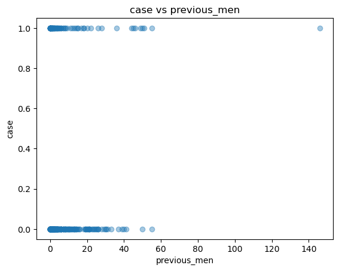

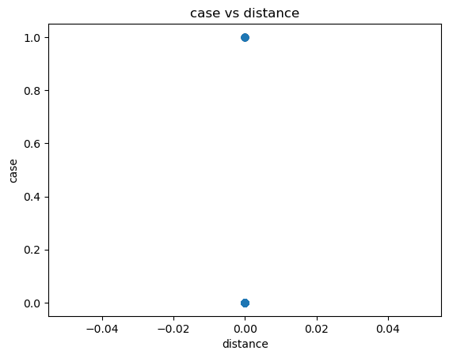

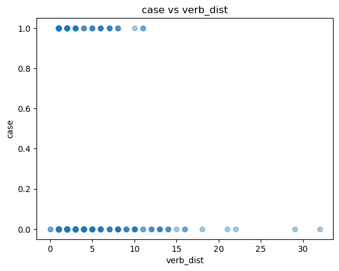

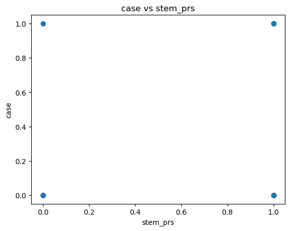

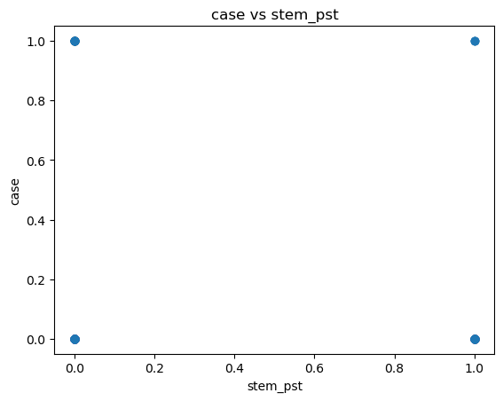

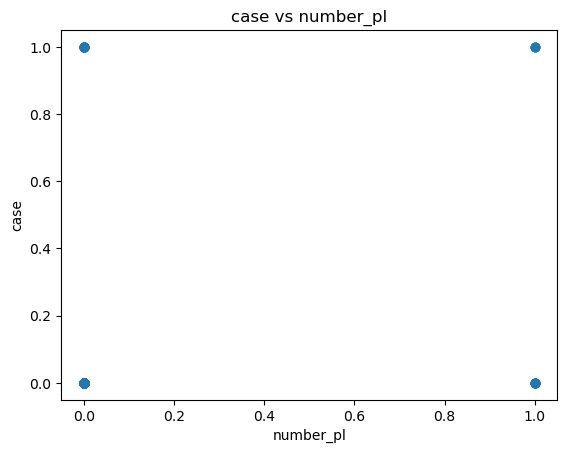

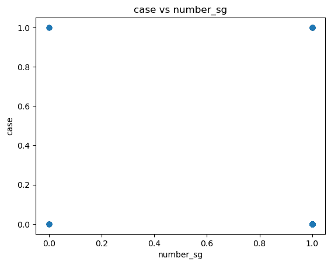

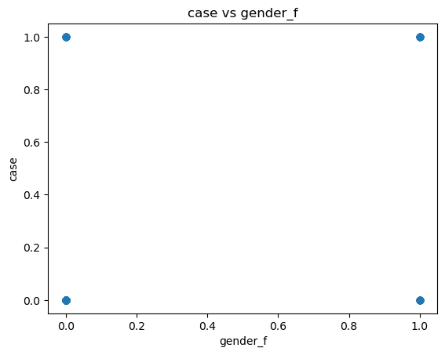

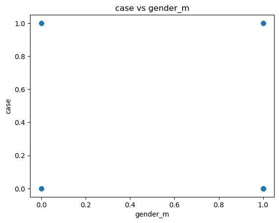

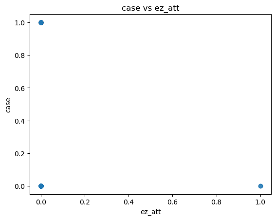

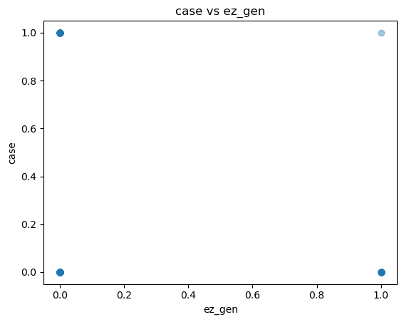

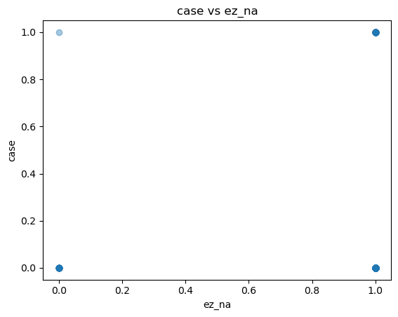

[3 more figures not shown]

```python
# Visualize data

for key in data:
    plt.scatter(data[[key]], labels, alpha=0.4)
    plt.xlabel(key)
    plt.ylabel("case")
    plt.title(f"case vs {key}")
    plt.show()
    plt.clf()
```

### Linear Regression

This model attempts to find the predictablitity from the data and labels OBL/DIR. The does not predict based on the current erroneous data set.

```
The model's accuracy on the training data is 0.4333964391079751.
The model's accuracy on the test data is 0.35011985797903633.
```

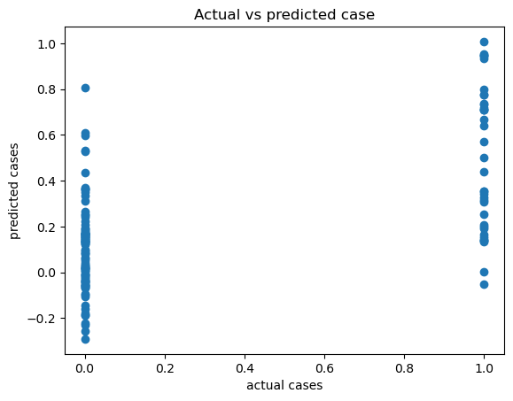

```python
# Train linear regression model

mlr = LinearRegression()
mlr.fit(train_data, train_labels)

predict_labels = mlr.predict(test_data)

print(f"The model's accuracy on the training data is {mlr.score(train_data, train_labels)}.")
print(f"The model's accuracy on the test data is {mlr.score(test_data, test_labels)}.")

plt.scatter(test_labels, predict_labels)
plt.xlabel("actual cases")
plt.ylabel("predicted cases")
plt.title("Actual vs predicted case")
plt.show()
plt.clf()
```

### Logistic regression

This model uses a differernt method of redicting the case.

**Terms:**

- Accuracy = (TP + TN)/(TP + FP + TN + FN)
- Precision = TP/(TP + FP)
- Recall = TP/(TP + FN)
- F1 score: weighted average of precision and recall
- TP: True Positive
- TN: True Negative
- FP: False Positive
- FN: False Negative

```python
cc_lr = LogisticRegression()
cc_lr.fit(train_data, train_labels)

# # Print the intercept and coefficients here:
# print(cc_lr.intercept_)
# print(cc_lr.coef_)

# # Print out the predicted outcomes for the test data
# print(cc_lr.predict(test_data))
# # Print out the predicted probabilities for the test data
# print(cc_lr.predict_proba(test_data)[:,1])
# # Print out the true outcomes for the test data
# print(test_labels)

# Save and print the predicted outcomes
pred_labels = cc_lr.predict(test_data)
print('predicted classes: \n', pred_labels)

# Print out the true outcomes for the test data
print('true classes: \n', test_labels)

# Print out the confusion matrix
from sklearn.metrics import confusion_matrix
print('confusion matrix: ')
print(confusion_matrix(test_labels, pred_labels))

# Print accuracy here:
from sklearn.metrics import accuracy_score
print('accuracy score: ')
print(accuracy_score(test_labels, pred_labels))

# Print F1 score here:
from sklearn.metrics import f1_score
print('f1 score: ')
print(f1_score(test_labels, pred_labels))
```

```
predicted classes:
 [0 0 0 0 0 0 0 0 1 0 0 0 0 0 0 1 0 0 0 0 0 1 0 0 0 1 0 0 0 0 0 0 0 0 0 0 0
 0 0 0 0 0 1 0 1 0 0 0 0 1 0 0 0 0 0 1 0 0 0 0 1 1 0 0 0 0 0 1 0 0 0 0 0 1
 0 0 0 0 0 0 0 0 0 0 1 0 1 0 0 0 0 0 0 1 0 0 0 1 1 0 0 1 0 0 0 1 0 0 0 0 0
 0 0 0 0 0 0 0 0 0 0 0 0 0 0 0 0 0 0 0 0 0 0 0 0 0 0]
true classes:
 102    0
125    0
11     0
248    0
238    0
      ..
221    1
320    0
19     0
212    1
44     0
Name: oblique, Length: 137, dtype: int64
confusion matrix:
[[97  2]
 [21 17]]
accuracy score:
0.8321167883211679
f1 score:
0.5964912280701755
```

### Decision Trees

This section is the most relevant to out work here. We create a deescision tree based on our data. It decides which features are predictive and creates a tree that reflects that.

```python
depths = range(1, 21)
acc_depth = []
for i in depths:
    dt = DecisionTreeClassifier(random_state = 10, max_depth = i, ccp_alpha=0.01,criterion='gini')
    dt.fit(train_data, train_labels)
    acc_depth.append(dt.score(test_data, test_labels))
```

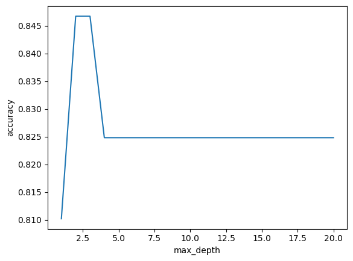

```python
#Plot the accuracy vs depth
plt.plot(depths, acc_depth)
plt.xlabel('max_depth')
plt.ylabel('accuracy')
plt.show()
```

### Refit the classifier on the new depth

```python
#Find the largest accuracy and the depth this occurs
max_acc = np.max(acc_depth)
best_depth = depths[np.argmax(acc_depth)]
print(f'Highest accuracy {round(max_acc,3)*100}% at depth {best_depth}')

#Refit decision tree model with the highest accuracy and plot the decision tree
plt.figure(figsize=(14,8))
dt = DecisionTreeClassifier(random_state = 10, max_depth = best_depth, ccp_alpha=0.01,criterion='gini')
dt.fit(data, labels)

# # Show decision tree
# tree.plot_tree(dt, feature_names = train_data.columns,
#                class_names = ['DIR', 'OBL'],
#                 filled=True)
# plt.show()
```

```
Highest accuracy 84.7% at depth 2
```

```
DecisionTreeClassifier(ccp_alpha=0.01, max_depth=2, random_state=10)
```

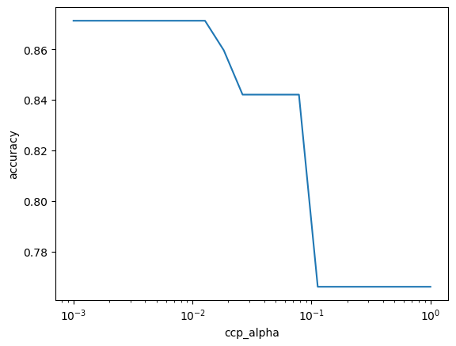

```python
#Create a new list for the accuracy values of a pruned decision tree.  Loop through
#the values of ccp and append the scores to the list
acc_pruned = []
ccp = np.logspace(-3, 0, num=20)
for i in ccp:
    dt_prune = DecisionTreeClassifier(random_state = 1, max_depth = best_depth, ccp_alpha=i)
    dt_prune.fit(data, labels)
    acc_pruned.append(dt_prune.score(data, labels))

plt.plot(ccp, acc_pruned)
plt.xscale('log')
plt.xlabel('ccp_alpha')
plt.ylabel('accuracy')
plt.show()
```

#### Interpreting the decision tree:

- The first element is the feature responsible for the split
- Splits are ordered by most explanitory without regard for what comes after
- True values split left
- False values split right
- Gini = $1 - (p^2_1 + p^2_2) = 1 - (p^2_1 + (1 - p_1)^2) $
- Low Gini impurity means more perfect splits
- Samples are the number of entries in the data used to make the decision
- Values: the numbers of each outcome: $[p_1, p_2]$
- class: default/most common value at this point

```
Highest accuracy 87.1% at ccp_alpha 0.001
```

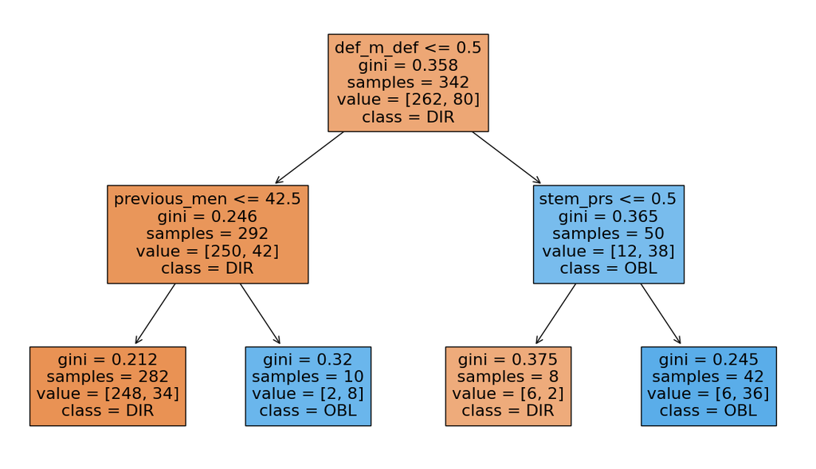

```python
#Find the largest accuracy and the ccp value this occurs
max_acc_pruned = np.max(acc_pruned)
best_ccp = ccp[np.argmax(acc_pruned)]

print(f'Highest accuracy {round(max_acc_pruned,3)*100}% at ccp_alpha {round(best_ccp,4)}')

#Fit a decision tree model with the values for max_depth and ccp_alpha found above
dt_final = DecisionTreeClassifier(random_state = 1, max_depth = best_depth, ccp_alpha=best_ccp)
# dt_final.fit(train_data, train_labels)
dt_final.fit(data, labels)

#Plot the final decision tree
plt.figure(figsize=(14,8))
tree.plot_tree(dt_final, feature_names = train_data.columns,
               class_names = ['DIR', 'OBL'],
                filled=True)
plt.show()
```

```python
df = pd.DataFrame({"feature": dt_final.feature_names_in_, "importance": dt_final.feature_importances_})

table2 = tabulate.tabulate(df, tablefmt='html',headers="keys")
table2
```

|  | feature | importance |
| --- | --- | --- |
| 0 | previous_men | 0.192637 |
| 1 | distance | 0 |
| 2 | verb_dist | 0 |
| 3 | stem_prs | 0.107036 |
| 4 | stem_pst | 0 |
| 5 | number_pl | 0 |
| 6 | number_sg | 0 |
| 7 | gender_f | 0 |
| 8 | gender_m | 0 |
| 9 | ez_att | 0 |
| 10 | ez_gen | 0 |
| 11 | ez_na | 0 |
| 12 | def_m_abs | 0 |
| 13 | def_m_def | 0.700327 |
| 14 | def_m_indf | 0 |